## Manuscript data with graphs

First I’ll read in the data.

```r
dat<-read.csv("Goal Orientation answersfinal.csv")
```

Then I’ll check the structure of the data and change any variables that should be factor variables into factor variables.

```r
str(dat)
```

```
## 'data.frame':    143 obs. of  3 variables:
##  $ Gender   : Factor w/ 2 levels "Female","Male": 2 1 1 1 1 1 2 1 2 1 ...
##  $ Condition: Factor w/ 3 levels "Mastery","Neutral",..: 1 1 1 1 1 1 1 1 1 1 ...
##  $ Result   : int  14 13 12 12 14 12 10 13 13 11 ...
```

```r
dat$Gender<-as.factor(dat$Gender)
dat$Condition<-as.factor(dat$Condition)
```

Now, I’ll perform a between-subjects 2-way ANOVA looking for effects between survey scores and whether or not participants were effected by the condition description provided, as well as the difference between scores in males and females. Then I’ll create line and grouped bar graph for the data I analyzed. But first I need to summarize the data.

```r
summary(aov(Result~Condition*Gender, data=dat))
```

```
##                   Df Sum Sq Mean Sq F value Pr(>F)
## Condition          2   23.6  11.781   4.125 0.0182 *
## Gender             1    5.8   5.837   2.044 0.1551
## Condition:Gender   2    0.1   0.056   0.020 0.9805
## Residuals        137  391.3   2.856
## ---
## Signif. codes:  0 '***' 0.001 '**' 0.01 '*' 0.05 '.' 0.1 ' ' 1
```

```r
library(ggplot2)
library(gplots)
library(dplyr)
```

Then I’ll create line and grouped bar graph for the data I analyzed. But first I need to summarize the data.

```r
temp<-dat%>%group_by(Condition,Gender)%>%
  summarize(means=mean(Result),
            sems=sd(Result)/sqrt(length(n)))
```

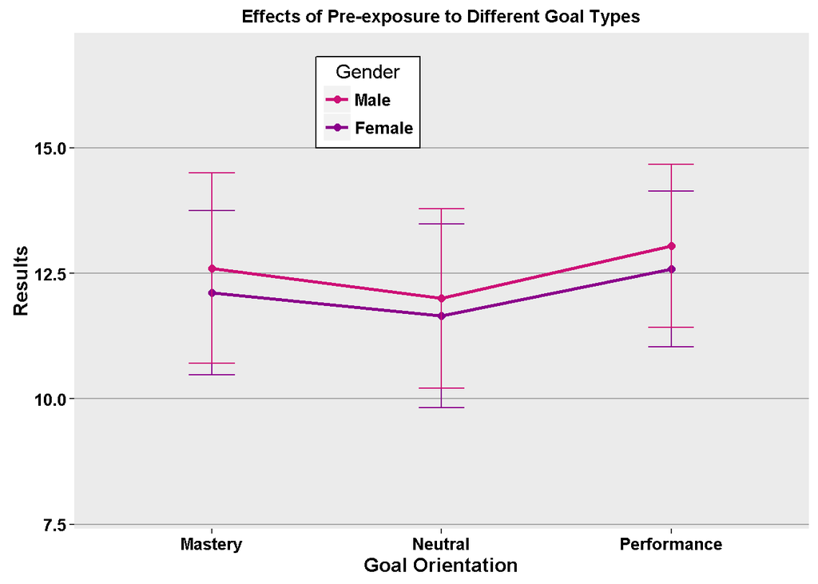

```r
f<-ggplot(temp, aes(x=Condition,
                    y=means,
                    group=Gender,
                    color=Gender))+
  geom_line(size=1)+
  geom_point(size=2)+
  scale_color_manual(values=c("dark magenta","deeppink3"),
                     name="Gender",
                     breaks=c("Male","Female"),
                     labels=c("Male", "Female"))+
  geom_errorbar(aes(ymax=means+sems, ymin=means-sems),width=.2)+
  ggtitle("Effects of Pre-exposure to Different Goal Types")+
  labs(x="Goal Orientation",y="Results")+
  theme(plot.title=element_text(size=11,face="bold",vjust=.5))+
  theme(axis.title.x=element_text(size=12,face="bold",vjust=-.25))+
  theme(axis.title.y=element_text(size=12,face="bold",vjust=1))+
  theme(axis.text.x=element_text(size=10,face="bold",color="black"))+
  theme(axis.text.y=element_text(size=10,face="bold",color="black"))+
  coord_cartesian(ylim=c(min(temp$means)-2*max(temp$sems),
                         max(temp$means)+2*max(temp$sems)))+
  theme(panel.border=element_blank(),axis.line=element_line())+
  theme(panel.grid.major.x=element_blank())+
  theme(panel.grid.major.y=element_line(color="darkgrey"))+
  theme(panel.grid.minor.y=element_blank())+
  theme(legend.position=c(.4,.86))+
  theme(legend.background=element_blank())+
  theme(legend.background=element_rect(color="black"))+
  theme(legend.title=element_blank())+
  theme(legend.title=element_text(size=12))+
  theme(legend.title.align=.5)+
  theme(legend.text=element_text(size=10,face="bold"))
f
```

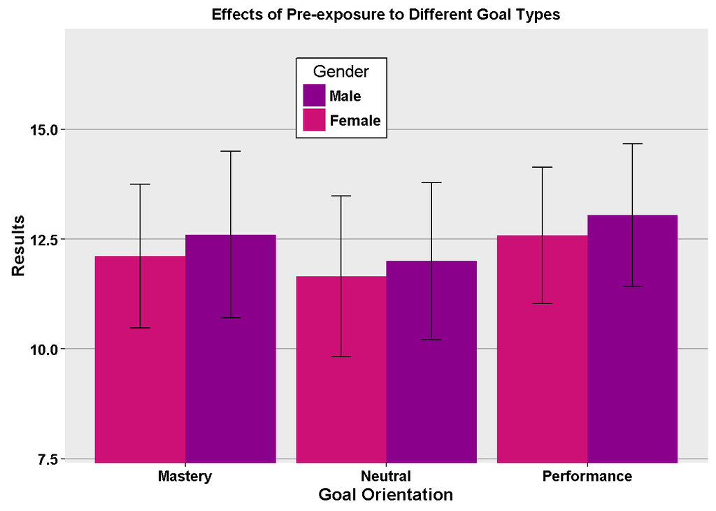

```r
f<-ggplot(temp, aes(x=Condition,
                    y=means,
                    fill=Gender))+
  geom_bar(stat="identity",position=position_dodge())+
  scale_fill_manual(values=c("deeppink3","dark magenta"),
                     name="Gender",
                     breaks=c("Male", "Female"),
                     labels=c("Male", "Female"))+
  geom_errorbar(aes(ymax=means+sems,
                    ymin=means-sems),
                width=.2,
                position=position_dodge(.9))+
  ggtitle("Effects of Pre-exposure to Different Goal Types")+
  labs(x="Goal Orientation",y="Results")+
  theme(plot.title=element_text(size=11,face="bold",vjust=.5))+
  theme(axis.title.x=element_text(size=12,face="bold",vjust=-.25))+
  theme(axis.title.y=element_text(size=12,face="bold",vjust=1))+
  theme(axis.text.x=element_text(size=10,face="bold",color="black"))+
  theme(axis.text.y=element_text(size=10,face="bold",color="black"))+
  coord_cartesian(ylim=c(min(temp$means)-2*max(temp$sems),
                         max(temp$means)+2*max(temp$sems)))+
  theme(panel.border=element_blank(),axis.line=element_line())+
  theme(panel.grid.major.x=element_blank())+
  theme(panel.grid.major.y=element_line(color="darkgrey"))+
  theme(panel.grid.minor.y=element_blank())+
  theme(legend.position=c(.43,.84))+
  theme(legend.background=element_blank())+
  theme(legend.background=element_rect(color="black"))+
  theme(legend.title=element_blank())+
  theme(legend.title=element_text(size=12))+
  theme(legend.title.align=.5)+
  theme(legend.text=element_text(size=10,face="bold"))
f
```

From the figures we can see that eventhough the participants were preexposed to a specific goal orientation prior to taking the survey, there was only a small effect on how they answered the survey and which goal orientation they identified as. We can also see that results of the survery did not present a significant change whether the participant was male or female. Finally, there was no effect on condition and gender within the interaction.